# Access Recovery Under Reservation and Horizon Flexibility

Final independent-evaluation findings from the 3×3 patient-behavior experiment

**Decision summary**

- **Both-flexible creates the largest Class 1 access shift** while keeping utilization nearly unchanged.
- **Reservation-only is much better at finding C1-win / C2-neutral compromises.**
- **No-show sensitivity matters more than balking sensitivity** for how much access-recovery room remains.
- **No independently validated win-win was found** in the headline range ($\rho \le 2.5$).

## Study lens

- **Primary comparison:** frozen access-recovery point vs. the **same policy’s average-utilization optimum**.
- **Favorable comparison:** frozen favorable candidate vs. the **matched no-policy baseline**.
- **Win-win:** both classes improve by at least **0.5 percentage points**, with paired-bootstrap 95% CIs above zero.
- **C1-win / C2-neutral:** Class 1 improves by at least **0.5 pp** with CI above zero, while the entire Class 2 CI lies within **±0.5 pp**.
- **Inference:** 10 independent evaluation seeds (2000–2009); 2,000 paired-bootstrap resamples.

## 1. Both-flexible creates the largest Class 1 access shift

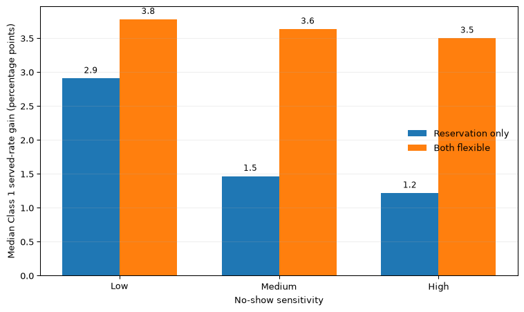

Figure 1: Median Class 1 served-rate gain from the frozen access-recovery point relative to the same policy’s average-utilization optimum. Values average the three balking-cell medians within each no-show tier.

- **Both-flexible:** median Class 1 gain is roughly **3.5–3.8 pp** across no-show tiers.
- **Reservation-only:** the median gain is smaller and falls as no-show sensitivity rises.
- Utilization remains very close to the original optimum: the median loss is only about **0.06 pp** for both-flexible and **0.04 pp** for reservation-only.

**Interpretation**

Both-flexible gives the optimizer the most room to move access toward Class 1 without materially changing utilization. The main question is whether that extra flexibility can do so **without harming Class 2**.

## 2. Reservation-only is much better at protecting Class 2

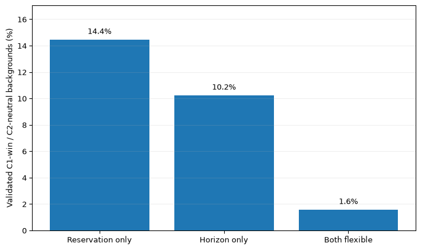

Figure 2: Share of headline backgrounds with at least one independently validated C1-win / C2-neutral outcome among the frozen favorable candidates.

- **Reservation-only** produces the largest set of robust C1-win / C2-neutral cases.
- **Both-flexible** produces very few such compromises even though it creates the largest raw Class 1 shift.
- **No policy produced an independently validated win-win.**

### Where do the favorable reservation-only outcomes occur?

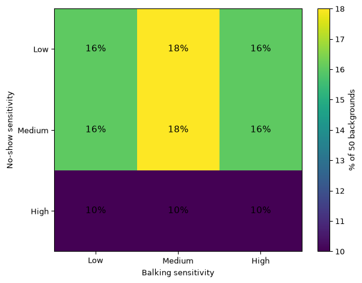

Figure 3: Reservation-only: independently validated C1-win / C2-neutral prevalence in each behavior cell. Denominator = 50 headline backgrounds per cell.

- Favorable reservation-only outcomes occur across the full 3×3 grid.
- The pattern is **nearly flat across balking levels** within each no-show row.
- High no-show reduces the favorable prevalence from roughly **16–18%** to about **10%**.

## Why might horizon flexibility make Class 2 harder to protect?

The current experiment suggests a concrete mechanism:

| Reservation only | Both flexible |
| --- | --- |
| Booking horizon is fixed at **H = 100**. | Horizon is searched over **H = 2–26**. |
| Near-term capacity can be protected for Class 1 while Class 2 can still spill into farther-future dates. | Reservation protects Class 1 **and** the horizon cap can remove some of Class 2’s farther-future fallback capacity. |
| A Class 2 patient displaced from an early slot may still remain serviceable later. | A displaced Class 2 patient has fewer dates into which demand can move. |
| Access can improve for Class 1 without necessarily changing Class 2’s eventual service probability. | The policy can generate a larger Class 1 shift, but the C2-neutral region becomes much smaller. |

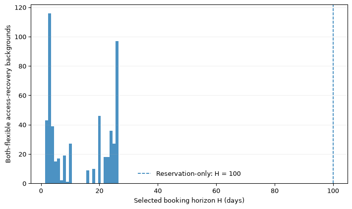

Figure 4: Both-flexible uses a short booking horizon at the frozen access-recovery point; reservation-only is fixed at H = 100. The short-horizon distribution is consistent with the proposed Class 2 fallback-capacity mechanism.

**Important design caveat**

**Both-flexible is not a strict superset of reservation-only in this experiment.**

Reservation-only uses **H = 100**, whereas both-flexible is restricted to **H = 2–26**. The observed difference is therefore **consistent with** a horizon-cap mechanism, but this experiment does not isolate its causal contribution.

A clean follow-up ablation would let both-flexible include **H = 100**. If C2-neutral outcomes increase when that option is available, it would directly support the fallback-capacity explanation.

## 3. No-show matters more than balking

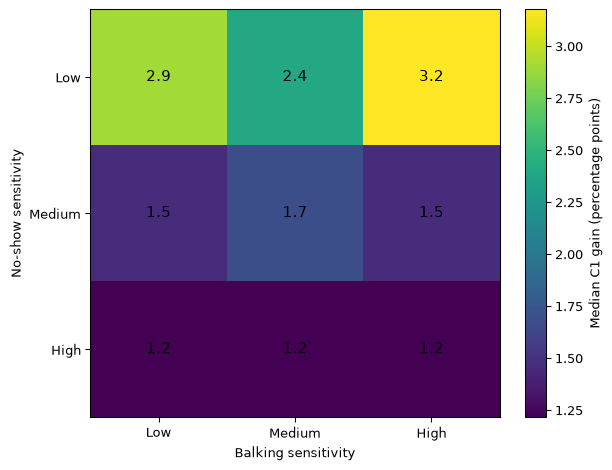

Figure 5: Reservation-only median Class 1 served-rate recovery versus the same policy’s utilization optimum. Variation is primarily across no-show rows rather than balking columns.

- **No-show sensitivity changes the magnitude of reservation-only’s access-recovery opportunity.**
- **Balking differences are small and non-monotonic** within the same no-show tier.
- For both-flexible, the Class 1 recovery is even more stable across the 3×3 behavior grid.

**How to reconcile this with the earlier utilization result**

Two statements can both be true:

- **Higher no-show makes flexibility more valuable relative to baseline utilization**, because flexibility helps avoid capacity being wasted by no-shows.
- **Lower no-show leaves more residual Class 1 access-recovery room after utilization has already been optimized.**

They answer different questions and use different reference points.

## Bottom line

- **Use both-flexible when the objective is the largest possible Class 1 access shift while holding utilization nearly fixed.**
- **Use reservation-only when the objective is a more conservative Class 1 improvement with a much better chance of leaving Class 2 neutral.**
- **No-show sensitivity is the behavioral dimension that most consistently changes the access tradeoff.**
- **Balking sensitivity is secondary in the final 3×3 results.**
- **No independently validated win-win was found.**